# Introduction to Support Vector Machines

31 January, 2018

## Outline

- Purpose and Intuition
- Separating Hyperplanes and the Maximal Margin Classifier
- Support Vector Classifiers
- Support Vector Machines with 2 classes

## Purpose and Intuition

- Classification technique used for separating observations into one of two classes
  - This can be extended to K > 2 classes using One-vs-One or One-vs-All classification
- Construct a decision boundary that divides the predictor space into two halves

## Hyperplanes - Definition

- **Definition:**
  - A **hyperplane** of a p-dimensional space is a flat subset with dimension p-1
  - For a 2-dimensional space, a **hyperplane** will just be a line; in 3 dimensions we have a 2-dimensional plane
- More formally:
  - Let \(\mathbb{\beta} \ne 0\) be a vector in \(\mathbb{R}^n\) and let \(a \in \mathbb{R}\)
  - A **hyperplane** \(H\) is then defined as the set:

\[ H = \{x \in \mathbb{R}^n \mid \beta \cdot x = a\} \]

## Hyperplanes - Definition

- A hyperplane in \(\mathbb{R}^2\) can be described with the following equation:

\[ \beta_0 + \beta_1X_1 + \beta_2X_2 = 0 \]

- We say that two sets \(D\) and \(E\) in \(\mathbb{R}^2\) are **separated** by the hyperplane \(H\) if we have

\[ \beta_0 + \beta_1X_1 + \beta_2X_2 \geq 0 ~~ \forall ~~ d \in D\\ \beta_0 + \beta_1X_1 + \beta_2X_2 \leq 0 ~~ \forall ~~ e \in E\\ \]

## Hyperplanes - Separation

\[ \beta_0 + \beta_1X_1 + \beta_2X_2 < 0 ~~~~ [1]\\ \beta_0 + \beta_1X_1 + \beta_2X_2 = 0 ~~~~ [2]\\ \beta_0 + \beta_1X_1 + \beta_2X_2 > 0 ~~~~ [3]\\ \]

- When we have an observation \(x = (x_1, x_2)\) that satisfies the first or third equation, we can get an idea of what side of the hyperplane it lies on
- If we have \([2]\) then \(x\) is simply a point on the hyperplane

## Hyperplanes - Example

- The hyperplane \(-3 + \frac{1}{4}X_1 + X_2 = 0\). The set of points \((x_1, x_2)\) for which this equation is greater than 0 are colored black, where those less than 0 are colored blue

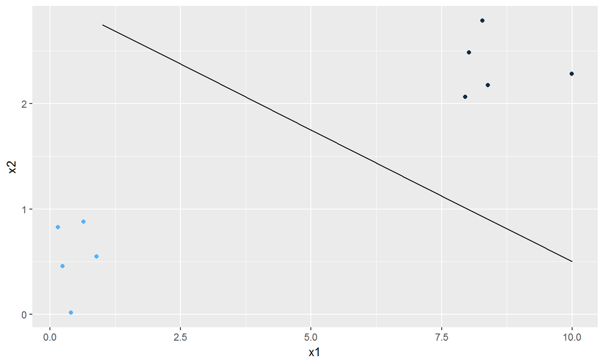

## The Maximal Margin Classifier

- Usually if we can define one hyperplane that separates our data, we can define many
- An intuitive choice for the *best* hyperplane is the one that is furthest from our training observations
  - Think of it as being the boundary that creates the most distance between the two groups

## The Maximal Margin Classifier

- For each hyperplane, we can find the distance to the closest observation
  - This is known as the **margin**
  - The points that are closest to each side of the hyperplane are called **support vectors**
- Hence, the **maximal margin classifier** will be the hyperplane for which the margin is the largest

## The Maximal Margin Classifier

- Can lead to overfitting in high-dimensional cases
- Usually unrealistic to assume that data is linearly separable
  - Even if it is, the margin might be small and sensitive to new observations
- Need to come up with less rigid solution to the classification problem

## Support Vector Classifiers

- Support Vector Classifiers loosen the requirement that all training observations lie on the correct side of a separating hyperplane
- We allow some observations to be misclassified for two reasons:
  - Allow our model to be more robust to individual observations (overfitting)
  - "Widen" our margin to allow for better classification on testing sets
- For these reasons Support Vector Classifiers are also known as *Soft Margin Classifiers*

## Support Vector Classifiers - Setup

- \(i = 1,..., n\) observations in the training set
- \(j = 1,..., p\) predictors
- \(y_i \in \{-1,1\}\) classes
- Our hyperplane will be defined as:

\[ \beta_0 + \beta_1X_1 + ... + \beta_pX_p = 0 \]

## Support Vector Classifiers - Setup

- A support vector classifier can then be described as the solution to the optimization problem:

\[ \begin{matrix} \displaystyle \max_{\beta, \epsilon} & M \\ \textrm{s.t.} & \sum_{j=1}^{p}{\beta_j^2}=1, \\ & y_i(\beta_0 + \beta_1x_{i1}+...+\beta_px_{ip}) \geq & M(1-\epsilon_i)\\ & \epsilon_i\geq0, \forall{i}\in 1,...,n \\ & \sum_{i=1}^{n}\epsilon_i \leq C\\ \end{matrix} \]

## Support Vector Classifiers - Setup

- \(M\) is the **margin** and is a positive number
- \(\sum_{j=1}^p\beta_j^2 = 1\) constrains the size of each \(\beta_j\)
- \(y_i(\beta_0 + \beta_1x_{i1}+...+\beta_px_{ip}) \geq M(1-\epsilon_i)\) ensures that each observation will fall on the correct side of the hyperplane, except for maybe a couple
  - Note that a hyperplane \(a_o + a_1x_1 +a_2x_2 = 0\) is still a hyperplane when it is multiplied by a scalar \(y(a_0 + a_1x_1 + a_2x_2) = 0\)
  - Also recall that \(y_i\) is either 1 or -1; \(y_i\) will give us an indication of which side of the hyperplane the observation is (above or below)

## Support Vector Classifiers - Setup

- Think of all the \(\epsilon_i\) as individual tolerances to violations of the hyperplane
  - When \(\epsilon_i < 1\), the observation will be within the margin (but still classified correctly)
  - In the case of \(\epsilon_i > 1\), our observation will be misclassified
  - \(\epsilon_i = 0\) implies that the observation is at least \(M\) distance away from the margin

## Support Vector Classifiers - Setup

- In total, we choose to only allow \(C\) amount of error
- \(C = 0\) implies that there is no tolerance at all, which is equivalent to the maximal margin classifier problem
- Larger and larger values of \(C\) increase the margin, allowing for less accuracy but lower variance
- \(C\) can be tuned using cross-validation

## Support Vector Classifiers - Example

```r
# Set up toy data to work with
set.seed(1)
dat <- tibble(
  x1 = rnorm(500),
  x2 = rnorm(500),
  y = factor(c(rep('A',250), (rep('B',250))))       # Y is a factor
)

# Add a little of separability between the classes
dat$x1[dat$y == "A"] <-  dat$x1[dat$y == "A"] + 4
```

## Support Vector Classifiers - Example

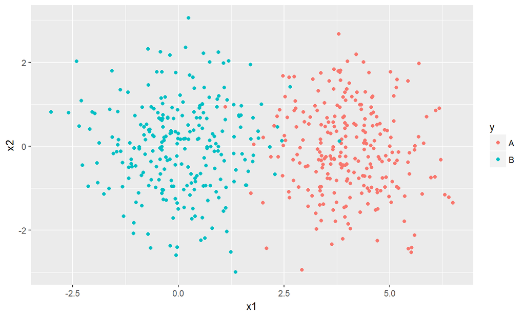

## Support Vector Classifiers - Example

```r
library("e1071")
svc <- svm(y ~ ., data = dat, kernel = 'linear',
           cost = 10, scale = FALSE)
```

## Support Vector Classifiers - Example

```
##
## Call:
## svm(formula = y ~ ., data = dat, kernel = "linear", cost = 10,
##     scale = FALSE)
##
##
## Parameters:
##    SVM-Type:  C-classification
##  SVM-Kernel:  linear
##        cost:  10
##       gamma:  0.5
##
## Number of Support Vectors:  30
##
##  ( 15 15 )
##
##
## Number of Classes:  2
##
## Levels:
##  A B
```

## Support Vector Classifiers - Example

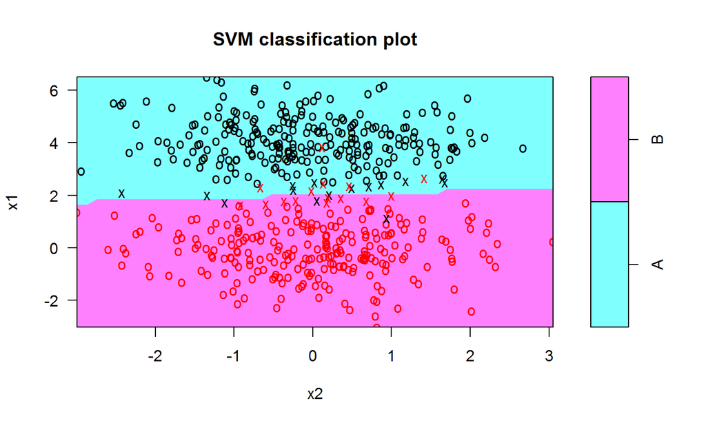

## Support Vector Classifiers - Tuning

- How do we decide on a value for our cost parameter \(C\)?
- `e1071::tune()` allows us to specify a range of values that it will test using 10-fold cross-validation

```r
svc_cv <-  tune(svm,y ~., data = dat, kernel = 'linear',
                ranges = list(
                  cost = c(.001, .01, .1, 1, 5, 10, 100)))
```

## Support Vector Classifiers - Tuning

- Extract the best performing model by grabbing the `best.model` component of `svc_cv`

```r
best_model <-  svc_cv$best.model
best_model
```

```
##
## Call:
## best.tune(method = svm, train.x = y ~ ., data = dat, ranges = list(cost = c(0.001,
##     0.01, 0.1, 1, 5, 10, 100)), kernel = "linear")
##
##
## Parameters:
##    SVM-Type:  C-classification
##  SVM-Kernel:  linear
##        cost:  0.01
##       gamma:  0.5
##
## Number of Support Vectors:  232
```

## Support Vector Classifiers - Prediction

```r
predictions <- predict(best_model, test)
table(predictions, truth = test$y)
```

```
##            truth
## predictions   A   B
##           A 243   5
##           B   7 245
```

## Non-linear Boundaries

What happens when we can't separate our data with a linear boundary?

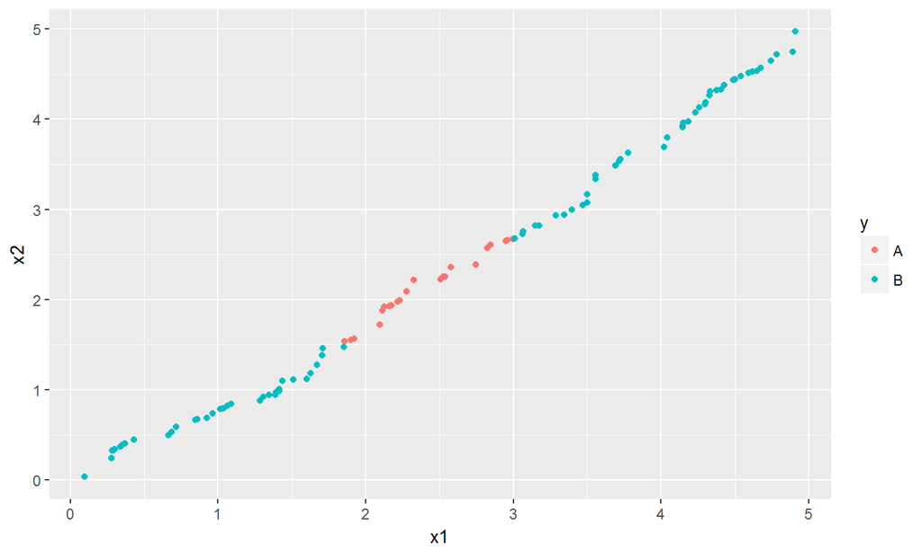

## Non-linear Boundaries

- Enlarge our feature space using functions of the predictors
  - \(X \mapsto \phi(X)\)
- Before we fit the SVC with \(p\) predictors:

\[ \begin{aligned} X_1,X_2,...,X_p \end{aligned} \]

- We could have fit the SVC with any amount of predictors to allow our boundary to deal with the non-linearity:

\[ \begin{aligned} X_1,X_2,...,X_p, X^2_1,X^2_2,...,X^2_p \end{aligned} \]

## Non-linear Boundaries - Example

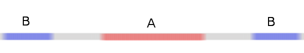

Groups **A** and **B** can't be separated with one boundary, but what if put this line into a 2-dimensional space?

## Non-linear Boundaries - Example

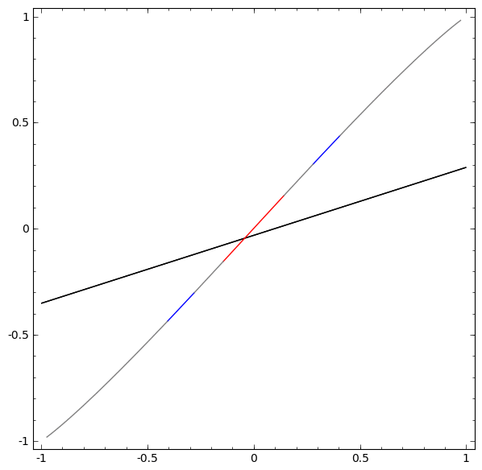

## Non-linear Boundaries - Computation

- The optimization problem described earlier is computed using the *inner products* of the support vectors
  - *inner products* can be thought as a measure of similarity between two observations
  - The inner product between two points \(x_1, x_2\) is denoted \(\langle x_1, x_2 \rangle\)

## Non-linear Boundaries - Computation

- Transforming our feature space \(X \mapsto \phi(X)\) could potentially make the computation much more difficult
  - instead of \(\langle x_1, x_2 \rangle\) we have \(\langle \phi(x_1), \phi(x_2) \rangle\)
  - could be super time consuming depending on \(\phi\)
- We can simplify this computation by knowing the **kernel function**

## Non-linear Boundaries - Kernels

- **Kernels** generalize inner products by allowing us to use different metrics of similarity
- SVCs have linear kernels
- A **kernel function** is usually written: \[ K(x_1, x_2) \]
- **Support Vector Machines** transform the feature space using kernels

## Support Vector Machines - Kernels

- A **support vector machine** is a combination of a support vector classifier with a non-linear kernel
- There are 3 very popular kernels:

\[ K(x_1,x_2) = (1 + \sum_{j=1}^px_{1j}x_{2j})^d ~~~ [1]\\ K(x_1, x_2) = exp(-\gamma\sum_{j=1}^p(x_{1j} - x_{2j})^2) ~~~ [2]\\ K(x_1, x_2) = tanh(\gamma\sum_{j=1}^px_{1j}x_{2j} + \delta) ~~~ [3]\\ \]

## Support Vector Machines - Kernels

- \([1]\) is called a *polynomial kernel* of degree *d*
- \([2]\) is the *radial basis function* and is very good at describing points close to a training observation
- \([3]\) is the *hyperbolic tangent* function

## Support Vector Machines - Example

- We use an artificial data set made to work well with a polynomial kernel

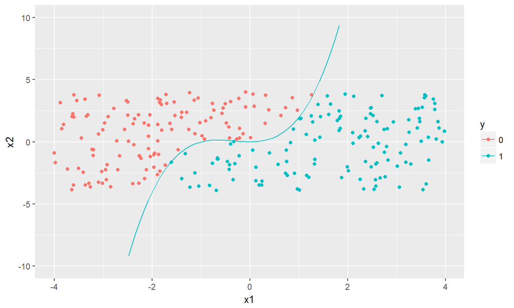

## Support Vector Machines - Example

- SVM with a polynomial kernel of degree 3

```r
svm_poly <-  svm(y ~., data = poly_dt, kernel = "polynomial")
```

## Support Vector Machines - Example

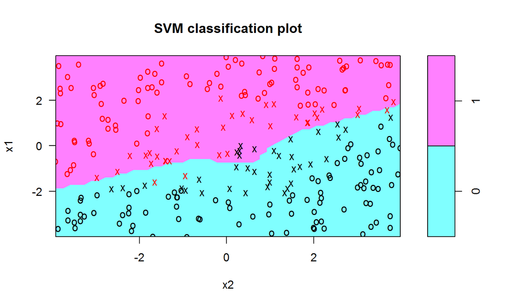

## Support Vector Machines - Example

- New data to predict:

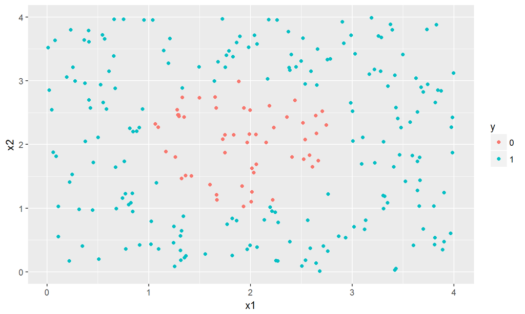

## Support Vector Machines - Example

- SVM with radial kernel

```r
svm_rad <-  svm(y ~ ., data = rad_dt, kernel = "radial",
                cost = 10)
```

## Support Vector Machines - Example

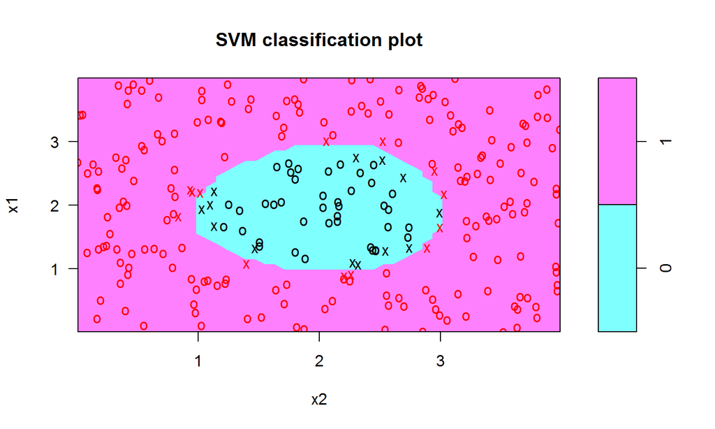

## Support Vector Machines - Tuning

- These non-linear kernel functions have new parameters that you have to choose yourself
  - Let CV do it for you!

```r
tune(svm, y ~ ., data = train, kernel = 'radial',
                ranges = list(cost = c(.1, 1, 10, 100, 1000),
                              gamma = c(.5, 1, 2, 3, 4)))
```

## Support Vector Machines - Evaluating

- Basic Workflow:
  - Define training and testing sets
  - Decide on a model (predictors, kernel, classes)
  - Use cross-validation to find hyperparameters with best training results (optional)
  - Evaluate best model using test set (ROC Curves, Classification Error, etc.)